title: “Coursera: Survival Analysis with R” author: “Yujin Zhang” date: “7/6/2022” output: html_document —

##Running a KM plot and log-rank test First, we load the dataset and do some variable manipulation.

```r
#load course data
tbl1 = read_csv(file = "./data/prcatice_data.csv") %>%
  janitor::clean_names() %>%
  mutate(gender = as.factor(gender)) %>%
  mutate(ethnicgroup = as.factor(ethnicgroup)) %>%
  mutate(copd = as.factor(copd))
skimr::skim(tbl1) #explore the dataset
```

Data summary

| Name | tbl1 |
| --- | --- |
| Number of rows | 1000 |
| Number of columns | 31 |
| _______________________ |  |
| Column type frequency: |  |
| factor | 3 |
| numeric | 28 |
| ________________________ |  |
| Group variables | None |

**Variable type: factor**

| skim_variable | n_missing | complete_rate | ordered | n_unique | top_counts |
| --- | --- | --- | --- | --- | --- |
| gender | 0 | 1.00 | FALSE | 2 | 1: 548, 2: 452 |
| copd | 0 | 1.00 | FALSE | 2 | 0: 758, 1: 242 |
| ethnicgroup | 43 | 0.96 | FALSE | 4 | 1: 889, 3: 34, 2: 17, 9: 17 |

**Variable type: numeric**

| skim_variable | n_missing | complete_rate | mean | sd | p0 | p25 | p50 | p75 | p100 | hist |
| --- | --- | --- | --- | --- | --- | --- | --- | --- | --- | --- |
| id | 0 | 1.00 | 500.50 | 288.82 | 1 | 250.75 | 500.5 | 750.25 | 1000 | ▇▇▇▇▇ |
| death | 0 | 1.00 | 0.49 | 0.50 | 0 | 0.00 | 0.0 | 1.00 | 1 | ▇▁▁▁▇ |
| los | 0 | 1.00 | 10.77 | 12.58 | 0 | 3.00 | 7.0 | 13.00 | 89 | ▇▁▁▁▁ |
| age | 0 | 1.00 | 78.73 | 11.14 | 29 | 73.00 | 80.0 | 87.00 | 102 | ▁▁▃▇▃ |
| cancer | 0 | 1.00 | 0.05 | 0.22 | 0 | 0.00 | 0.0 | 0.00 | 1 | ▇▁▁▁▁ |
| cabg | 0 | 1.00 | 0.01 | 0.12 | 0 | 0.00 | 0.0 | 0.00 | 1 | ▇▁▁▁▁ |
| crt | 0 | 1.00 | 0.00 | 0.05 | 0 | 0.00 | 0.0 | 0.00 | 1 | ▇▁▁▁▁ |
| defib | 0 | 1.00 | 0.01 | 0.08 | 0 | 0.00 | 0.0 | 0.00 | 1 | ▇▁▁▁▁ |
| dementia | 0 | 1.00 | 0.05 | 0.21 | 0 | 0.00 | 0.0 | 0.00 | 1 | ▇▁▁▁▁ |
| diabetes | 0 | 1.00 | 0.28 | 0.45 | 0 | 0.00 | 0.0 | 1.00 | 1 | ▇▁▁▁▃ |
| hypertension | 0 | 1.00 | 0.62 | 0.49 | 0 | 0.00 | 1.0 | 1.00 | 1 | ▅▁▁▁▇ |
| ihd | 0 | 1.00 | 0.50 | 0.50 | 0 | 0.00 | 0.0 | 1.00 | 1 | ▇▁▁▁▇ |
| mental_health | 0 | 1.00 | 0.09 | 0.28 | 0 | 0.00 | 0.0 | 0.00 | 1 | ▇▁▁▁▁ |
| arrhythmias | 0 | 1.00 | 0.49 | 0.50 | 0 | 0.00 | 0.0 | 1.00 | 1 | ▇▁▁▁▇ |
| obesity | 0 | 1.00 | 0.06 | 0.23 | 0 | 0.00 | 0.0 | 0.00 | 1 | ▇▁▁▁▁ |
| pvd | 0 | 1.00 | 0.10 | 0.30 | 0 | 0.00 | 0.0 | 0.00 | 1 | ▇▁▁▁▁ |
| renal_disease | 0 | 1.00 | 0.25 | 0.43 | 0 | 0.00 | 0.0 | 0.00 | 1 | ▇▁▁▁▂ |
| valvular_disease | 0 | 1.00 | 0.24 | 0.43 | 0 | 0.00 | 0.0 | 0.00 | 1 | ▇▁▁▁▂ |
| metastatic_cancer | 0 | 1.00 | 0.01 | 0.09 | 0 | 0.00 | 0.0 | 0.00 | 1 | ▇▁▁▁▁ |
| pacemaker | 0 | 1.00 | 0.04 | 0.19 | 0 | 0.00 | 0.0 | 0.00 | 1 | ▇▁▁▁▁ |
| pneumonia | 0 | 1.00 | 0.12 | 0.32 | 0 | 0.00 | 0.0 | 0.00 | 1 | ▇▁▁▁▁ |
| prior_appts_attended | 0 | 1.00 | 5.54 | 6.84 | 0 | 1.00 | 3.0 | 8.00 | 62 | ▇▁▁▁▁ |
| prior_dnas | 0 | 1.00 | 0.50 | 1.11 | 0 | 0.00 | 0.0 | 1.00 | 10 | ▇▁▁▁▁ |
| pci | 0 | 1.00 | 0.03 | 0.17 | 0 | 0.00 | 0.0 | 0.00 | 1 | ▇▁▁▁▁ |
| stroke | 0 | 1.00 | 0.02 | 0.14 | 0 | 0.00 | 0.0 | 0.00 | 1 | ▇▁▁▁▁ |
| senile | 0 | 1.00 | 0.04 | 0.21 | 0 | 0.00 | 0.0 | 0.00 | 1 | ▇▁▁▁▁ |
| quintile | 6 | 0.99 | 3.16 | 1.37 | 0 | 2.00 | 3.0 | 4.00 | 5 | ▅▇▇▇▇ |
| fu_time | 0 | 1.00 | 465.95 | 338.99 | 0 | 117.75 | 475.0 | 743.25 | 1107 | ▇▃▅▅▃ |

Then we run overall KM method.

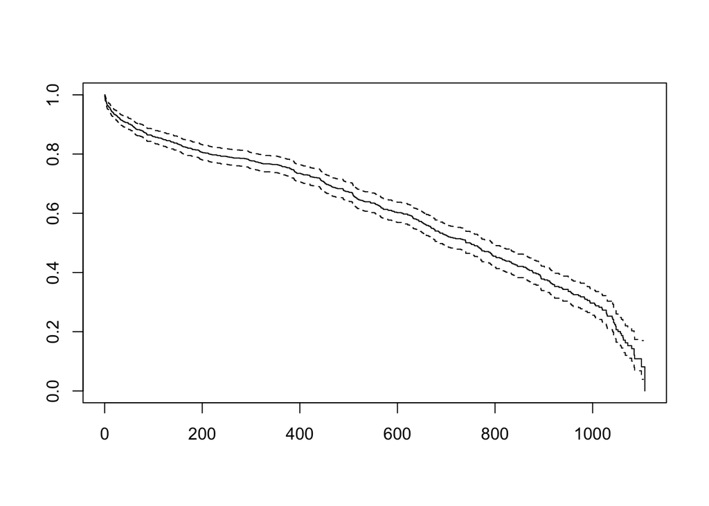

```r
km_fit = survfit(Surv(fu_time, death) ~ 1,data = tbl1) #call overall k-m plot
plot(km_fit)
```

```r
summary(km_fit, times = c(1:7,30,60,90*(1:10)))
```

```
## Call: survfit(formula = Surv(fu_time, death) ~ 1, data = tbl1)
##
##  time n.risk n.event survival std.err lower 95% CI upper 95% CI
##     1    992      12    0.988 0.00346        0.981        0.995
##     2    973       7    0.981 0.00435        0.972        0.989
##     3    963       5    0.976 0.00489        0.966        0.985
##     4    954       6    0.970 0.00546        0.959        0.980
##     5    945       5    0.964 0.00590        0.953        0.976
##     6    938       1    0.963 0.00598        0.952        0.975
##     7    933       1    0.962 0.00606        0.951        0.974
##    30    865      39    0.921 0.00865        0.905        0.939
##    60    809      28    0.891 0.01010        0.871        0.911
##    90    770      24    0.864 0.01117        0.843        0.887
##   180    698      43    0.815 0.01282        0.790        0.841
##   270    653      24    0.787 0.01363        0.760        0.814
##   360    619      21    0.761 0.01428        0.733        0.789
##   450    525      44    0.705 0.01554        0.675        0.736
##   540    429      47    0.639 0.01681        0.607        0.673
##   630    362      32    0.589 0.01765        0.556        0.625
##   720    266      43    0.514 0.01876        0.479        0.552
##   810    190      31    0.448 0.01979        0.411        0.488
##   900    126      26    0.378 0.02098        0.339        0.421
```

Run KM method by gender

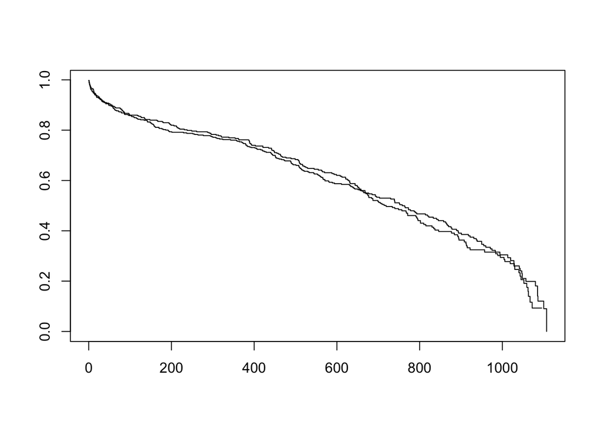

```r
km_gender = survfit(Surv(fu_time, death) ~ gender,data = tbl1) #split the curve by gender
plot(km_gender)
```

```r
survdiff(Surv(fu_time, death) ~ gender, data = tbl1) #compare survival curve
```

```
## Call:
## survdiff(formula = Surv(fu_time, death) ~ gender, data = tbl1)
##
##            N Observed Expected (O-E)^2/E (O-E)^2/V
## gender=1 548      268      271    0.0365     0.082
## gender=2 452      224      221    0.0448     0.082
##
##  Chisq= 0.1  on 1 degrees of freedom, p= 0.8
```

##Running Simple Cox Model

```r
cox_mod = coxph(Surv(fu_time, death) ~ ethnicgroup, data = tbl1)
summary(cox_mod)
```

```
## Call:
## coxph(formula = Surv(fu_time, death) ~ ethnicgroup, data = tbl1)
##
##   n= 957, number of events= 471
##    (43 observations deleted due to missingness)
##
##                  coef exp(coef) se(coef)      z Pr(>|z|)
## ethnicgroup2 -0.06428   0.93774  0.32000 -0.201  0.84078
## ethnicgroup3 -1.19586   0.30244  0.41108 -2.909  0.00362 **
## ethnicgroup9  0.07394   1.07674  0.35706  0.207  0.83596
## ---
## Signif. codes:  0 '***' 0.001 '**' 0.01 '*' 0.05 '.' 0.1 ' ' 1
##
##              exp(coef) exp(-coef) lower .95 upper .95
## ethnicgroup2    0.9377     1.0664    0.5008    1.7558
## ethnicgroup3    0.3024     3.3064    0.1351    0.6769
## ethnicgroup9    1.0767     0.9287    0.5348    2.1679
##
## Concordance= 0.516  (se = 0.006 )
## Likelihood ratio test= 12.99  on 3 df,   p=0.005
## Wald test            = 8.55  on 3 df,   p=0.04
## Score (logrank) test = 9.61  on 3 df,   p=0.02
```

About missing data:  
1. should be missing at random (example of survey data/not random)  
2. the process to treat missing data: understand why those data are missing- try to fill in the missing values on the basis of another variable- complete case analysis/ mean substitution/ multiple imputation/ maximum likelihood

##Running Multiple Cox Model

```r
cox_mod2 = coxph(Surv(fu_time, death) ~ ethnicgroup+age+gender+copd+prior_dnas, data = tbl1)
summary(cox_mod2)
```

```
## Call:
## coxph(formula = Surv(fu_time, death) ~ ethnicgroup + age + gender +
##     copd + prior_dnas, data = tbl1)
##
##   n= 957, number of events= 471
##    (43 observations deleted due to missingness)
##
##                   coef exp(coef)  se(coef)      z Pr(>|z|)
## ethnicgroup2 -0.300372  0.740543  0.354585 -0.847  0.39693
## ethnicgroup3 -0.794072  0.452000  0.414508 -1.916  0.05540 .
## ethnicgroup9  0.410506  1.507581  0.360902  1.137  0.25535
## age           0.064765  1.066909  0.005719 11.324  < 2e-16 ***
## gender2      -0.277178  0.757920  0.096227 -2.880  0.00397 **
## copd1         0.085753  1.089537  0.106380  0.806  0.42019
## prior_dnas    0.166117  1.180712  0.040028  4.150 3.32e-05 ***
## ---
## Signif. codes:  0 '***' 0.001 '**' 0.01 '*' 0.05 '.' 0.1 ' ' 1
##
##              exp(coef) exp(-coef) lower .95 upper .95
## ethnicgroup2    0.7405     1.3504    0.3696    1.4838
## ethnicgroup3    0.4520     2.2124    0.2006    1.0185
## ethnicgroup9    1.5076     0.6633    0.7432    3.0583
## age             1.0669     0.9373    1.0550    1.0789
## gender2         0.7579     1.3194    0.6276    0.9152
## copd1           1.0895     0.9178    0.8845    1.3421
## prior_dnas      1.1807     0.8469    1.0916    1.2771
##
## Concordance= 0.671  (se = 0.013 )
## Likelihood ratio test= 170.9  on 7 df,   p=<2e-16
## Wald test            = 143.6  on 7 df,   p=<2e-16
## Score (logrank) test = 141.5  on 7 df,   p=<2e-16
```

What to do when model does not converge:

```r
tbl2 =
  tbl1 %>%
  mutate(quintile = as.factor(quintile))

cox_uncon = coxph(Surv(fu_time, death) ~ age + gender + copd + quintile + ethnicgroup, data = tbl2)
summary(cox_uncon)
```

```
## Call:
## coxph(formula = Surv(fu_time, death) ~ age + gender + copd +
##     quintile + ethnicgroup, data = tbl2)
##
##   n= 951, number of events= 468
##    (49 observations deleted due to missingness)
##
##                    coef  exp(coef)   se(coef)      z Pr(>|z|)
## age           6.213e-02  1.064e+00  5.606e-03 11.082  < 2e-16 ***
## gender2      -3.104e-01  7.332e-01  9.695e-02 -3.201  0.00137 **
## copd1         6.439e-02  1.067e+00  1.092e-01  0.590  0.55548
## quintile1     1.422e+01  1.501e+06  9.177e+02  0.015  0.98764
## quintile2     1.391e+01  1.094e+06  9.177e+02  0.015  0.98791
## quintile3     1.431e+01  1.638e+06  9.177e+02  0.016  0.98756
## quintile4     1.427e+01  1.579e+06  9.177e+02  0.016  0.98759
## quintile5     1.430e+01  1.631e+06  9.177e+02  0.016  0.98756
## ethnicgroup2  1.402e-02  1.014e+00  3.261e-01  0.043  0.96570
## ethnicgroup3 -7.728e-01  4.617e-01  4.167e-01 -1.854  0.06369 .
## ethnicgroup9  5.211e-01  1.684e+00  3.623e-01  1.438  0.15038
## ---
## Signif. codes:  0 '***' 0.001 '**' 0.01 '*' 0.05 '.' 0.1 ' ' 1
##
##              exp(coef) exp(-coef) lower .95 upper .95
## age          1.064e+00  9.398e-01    1.0525    1.0759
## gender2      7.332e-01  1.364e+00    0.6063    0.8866
## copd1        1.067e+00  9.376e-01    0.8610    1.3211
## quintile1    1.501e+06  6.660e-07    0.0000       Inf
## quintile2    1.094e+06  9.141e-07    0.0000       Inf
## quintile3    1.638e+06  6.107e-07    0.0000       Inf
## quintile4    1.579e+06  6.332e-07    0.0000       Inf
## quintile5    1.631e+06  6.131e-07    0.0000       Inf
## ethnicgroup2 1.014e+00  9.861e-01    0.5352    1.9217
## ethnicgroup3 4.617e-01  2.166e+00    0.2040    1.0450
## ethnicgroup9 1.684e+00  5.939e-01    0.8277    3.4254
##
## Concordance= 0.67  (se = 0.013 )
## Likelihood ratio test= 169.6  on 11 df,   p=<2e-16
## Wald test            = 142.4  on 11 df,   p=<2e-16
## Score (logrank) test = 143.1  on 11 df,   p=<2e-16
```

```r
# 1. change the reference category
tbl2 =
  tbl2 %>%
  mutate(quintile = relevel(quintile, ref = 2)) #quintile 1 as the ref cat

cox_uncon = coxph(Surv(fu_time, death) ~ age + gender + copd + quintile + ethnicgroup, data = tbl2)
summary(cox_uncon)
```

```
## Call:
## coxph(formula = Surv(fu_time, death) ~ age + gender + copd +
##     quintile + ethnicgroup, data = tbl2)
##
##   n= 951, number of events= 468
##    (49 observations deleted due to missingness)
##
##                    coef  exp(coef)   se(coef)      z Pr(>|z|)
## age           6.213e-02  1.064e+00  5.606e-03 11.082  < 2e-16 ***
## gender2      -3.104e-01  7.332e-01  9.695e-02 -3.201  0.00137 **
## copd1         6.439e-02  1.067e+00  1.092e-01  0.590  0.55548
## quintile0    -1.422e+01  6.660e-07  9.177e+02 -0.015  0.98764
## quintile2    -3.167e-01  7.286e-01  1.592e-01 -1.988  0.04676 *
## quintile3     8.680e-02  1.091e+00  1.533e-01  0.566  0.57126
## quintile4     5.057e-02  1.052e+00  1.538e-01  0.329  0.74225
## quintile5     8.287e-02  1.086e+00  1.596e-01  0.519  0.60350
## ethnicgroup2  1.403e-02  1.014e+00  3.261e-01  0.043  0.96570
## ethnicgroup3 -7.728e-01  4.617e-01  4.167e-01 -1.854  0.06369 .
## ethnicgroup9  5.211e-01  1.684e+00  3.623e-01  1.438  0.15038
## ---
## Signif. codes:  0 '***' 0.001 '**' 0.01 '*' 0.05 '.' 0.1 ' ' 1
##
##              exp(coef) exp(-coef) lower .95 upper .95
## age          1.064e+00  9.398e-01    1.0525    1.0759
## gender2      7.332e-01  1.364e+00    0.6063    0.8866
## copd1        1.067e+00  9.376e-01    0.8610    1.3211
## quintile0    6.660e-07  1.501e+06    0.0000       Inf
## quintile2    7.286e-01  1.373e+00    0.5332    0.9955
## quintile3    1.091e+00  9.169e-01    0.8076    1.4729
## quintile4    1.052e+00  9.507e-01    0.7782    1.4218
## quintile5    1.086e+00  9.205e-01    0.7946    1.4853
## ethnicgroup2 1.014e+00  9.861e-01    0.5352    1.9217
## ethnicgroup3 4.617e-01  2.166e+00    0.2040    1.0450
## ethnicgroup9 1.684e+00  5.939e-01    0.8277    3.4254
##
## Concordance= 0.67  (se = 0.013 )
## Likelihood ratio test= 169.6  on 11 df,   p=<2e-16
## Wald test            = 142.4  on 11 df,   p=<2e-16
## Score (logrank) test = 143.1  on 11 df,   p=<2e-16
```

```r
#still not converge

# 2. combine categories
tbl2 =
  tbl1 %>%
  mutate(quintile_5grp = quintile) %>%
  mutate(quintile_5grp = replace(quintile_5grp, quintile_5grp == "0", "5"),
         quintile_5grp = factor(quintile_5grp))

cox_con = coxph(Surv(fu_time, death) ~ age + gender + copd + quintile + ethnicgroup, data = tbl2)
summary(cox_con)
```

```
## Call:
## coxph(formula = Surv(fu_time, death) ~ age + gender + copd +
##     quintile + ethnicgroup, data = tbl2)
##
##   n= 951, number of events= 468
##    (49 observations deleted due to missingness)
##
##                   coef exp(coef)  se(coef)      z Pr(>|z|)
## age           0.062452  1.064443  0.005635 11.082  < 2e-16 ***
## gender2      -0.278350  0.757031  0.096478 -2.885  0.00391 **
## copd1         0.044956  1.045982  0.108316  0.415  0.67811
## quintile      0.068762  1.071181  0.035380  1.944  0.05195 .
## ethnicgroup2  0.009406  1.009450  0.325074  0.029  0.97692
## ethnicgroup3 -0.796419  0.450941  0.415449 -1.917  0.05524 .
## ethnicgroup9  0.463197  1.589146  0.360763  1.284  0.19916
## ---
## Signif. codes:  0 '***' 0.001 '**' 0.01 '*' 0.05 '.' 0.1 ' ' 1
##
##              exp(coef) exp(-coef) lower .95 upper .95
## age             1.0644     0.9395    1.0528    1.0763
## gender2         0.7570     1.3209    0.6266    0.9146
## copd1           1.0460     0.9560    0.8459    1.2934
## quintile        1.0712     0.9335    0.9994    1.1481
## ethnicgroup2    1.0095     0.9906    0.5338    1.9089
## ethnicgroup3    0.4509     2.2176    0.1998    1.0180
## ethnicgroup9    1.5891     0.6293    0.7836    3.2229
##
## Concordance= 0.665  (se = 0.013 )
## Likelihood ratio test= 159.2  on 7 df,   p=<2e-16
## Wald test            = 134.2  on 7 df,   p=<2e-16
## Score (logrank) test = 132.4  on 7 df,   p=<2e-16
```

```r
# 3. drop the quintile zero(set to null)
tbl2 =
  tbl1 %>%
  mutate(quintile_5grp = quintile) %>%
  mutate(quintile_5grp = replace(quintile_5grp, quintile_5grp == "0", NA),
         quintile_5grp = factor(quintile_5grp))

cox_con = coxph(Surv(fu_time, death) ~ age + gender + copd + quintile + ethnicgroup, data = tbl2)
summary(cox_con)
```

```
## Call:
## coxph(formula = Surv(fu_time, death) ~ age + gender + copd +
##     quintile + ethnicgroup, data = tbl2)
##
##   n= 951, number of events= 468
##    (49 observations deleted due to missingness)
##
##                   coef exp(coef)  se(coef)      z Pr(>|z|)
## age           0.062452  1.064443  0.005635 11.082  < 2e-16 ***
## gender2      -0.278350  0.757031  0.096478 -2.885  0.00391 **
## copd1         0.044956  1.045982  0.108316  0.415  0.67811
## quintile      0.068762  1.071181  0.035380  1.944  0.05195 .
## ethnicgroup2  0.009406  1.009450  0.325074  0.029  0.97692
## ethnicgroup3 -0.796419  0.450941  0.415449 -1.917  0.05524 .
## ethnicgroup9  0.463197  1.589146  0.360763  1.284  0.19916
## ---
## Signif. codes:  0 '***' 0.001 '**' 0.01 '*' 0.05 '.' 0.1 ' ' 1
##
##              exp(coef) exp(-coef) lower .95 upper .95
## age             1.0644     0.9395    1.0528    1.0763
## gender2         0.7570     1.3209    0.6266    0.9146
## copd1           1.0460     0.9560    0.8459    1.2934
## quintile        1.0712     0.9335    0.9994    1.1481
## ethnicgroup2    1.0095     0.9906    0.5338    1.9089
## ethnicgroup3    0.4509     2.2176    0.1998    1.0180
## ethnicgroup9    1.5891     0.6293    0.7836    3.2229
##
## Concordance= 0.665  (se = 0.013 )
## Likelihood ratio test= 159.2  on 7 df,   p=<2e-16
## Wald test            = 134.2  on 7 df,   p=<2e-16
## Score (logrank) test = 132.4  on 7 df,   p=<2e-16
```

##Checking the proportionality assumption

```r
#default arguments: cox.zph(fit, transform = "km", global = TRUE)

fit = coxph(Surv(fu_time, death) ~ gender, data = tbl2)
temp = cox.zph(fit)

print(temp)
```

```
##        chisq df    p
## gender  1.24  1 0.26
## GLOBAL  1.24  1 0.26
```

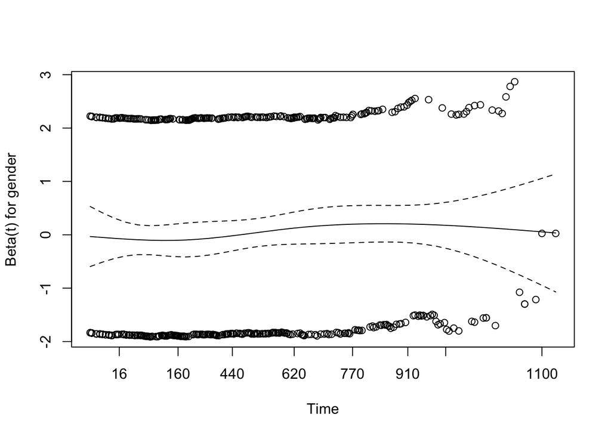

```r
plot(temp)
```

The line is pretty flat, meaning that the effect of gender little during the follow-up. That’s good news.  
Also, we can use ‘ggcoxzh()’, which produces graphs pf the scaled Schoenfield residuals against the transformed time for each covariate.

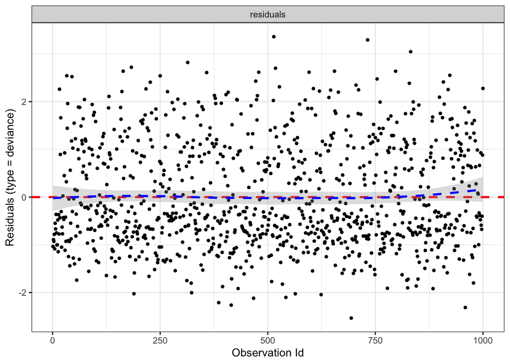

```r
#deviance residuals

res.cox = coxph(Surv(fu_time, death) ~ age, data = tbl2)
ggcoxdiagnostics(res.cox, type = "deviance",
                 linear.predictions = FALSE, ggtheme = theme_bw())
```

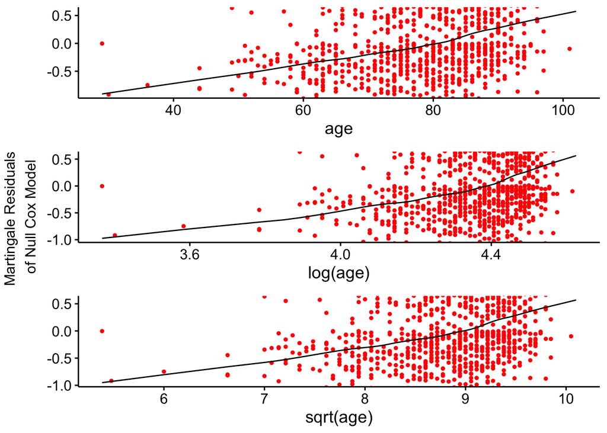

```r
#test linear relation
ggcoxfunctional(Surv(fu_time, death) ~ age + log(age) + sqrt(age), data = tbl2)
```

##Proportionality assumption not met

If there is a statistical interaction between gender and time for example. Then the model is short of a coefficient.

```r
#test statistically significant
fit = coxph(Surv(fu_time, death) ~ gender + tt(gender), data = tbl2) # 'tt' -> time-transform function
summary(fit)
```

```
## Call:
## coxph(formula = Surv(fu_time, death) ~ gender + tt(gender), data = tbl2)
##
##   n= 1000, number of events= 492
##
##               coef exp(coef) se(coef)      z Pr(>|z|)
## gender2     0.6405    1.8974   0.9800  0.654    0.513
## tt(gender) -0.2003    0.8185   0.3182 -0.629    0.529
##
##            exp(coef) exp(-coef) lower .95 upper .95
## gender2       1.8974      0.527    0.2779    12.953
## tt(gender)    0.8185      1.222    0.4387     1.527
##
## Concordance= 0.497  (se = 0.013 )
## Likelihood ratio test= 0.49  on 2 df,   p=0.8
## Wald test            = 0.48  on 2 df,   p=0.8
## Score (logrank) test = 0.48  on 2 df,   p=0.8
```

##Choose predictors

Apply backwards method